# BellaBeat Case Study

Mishika

2021-11-30

[figure not shown]

## Introduction

Bellabeat is a high-tech manufacturer of health-focused products for women. Collecting data on activity, sleep, stress, and reproductive health has allowed Bellabeat to empower women with knowledge about their own health and habits. Although Bellabeat is a successful small company, they have the potential to become a larger player in the global smart device market. Urška Sršen, cofounder and Chief Creative Officer of Bellabeat, believes that analyzing smart device fitness data could help unlock new growth opportunities for the company.

### Step 1: Ask

#### Business Task

To identify potential opportunities for growth and provide recommendations for the Bellabeat marketing strategy improvement based on trends in smart device usage.

#### Key Stakeholders

- Urška Sršen: Bellabeat’s cofounder and Chief Creative Officer
- Sando Mur: Mathematician and Bellabeat’s co-founder

#### Key questions to explore

1. What are some trends in smart device usage?
2. How could these trends apply to Bellabeat customers?
3. How could these trends help influence Bellabeat marketing strategy?

### Step 2: Prepare

The data being used in this case study can be found here: [FitBit Fitness Tracker Data](https://www.kaggle.com/datasets/arashnic/fitbit?resource=download)

The data is stored and uploaded in R Studio. This Kaggle data set contains personal fitness tracker from thirty fitbit users. Thirty eligible Fitbit users consented to the submission of personal tracker data, including minute-level output for physical activity, heart rate, and sleep monitoring. It includes information about daily activity, steps, and heart rate that can be used to explore users’ habits.

The dataset has 18 CSV. The data also follow a ROCCC approach:

- **Reliability**: The data is from 30 FitBit users who consented to the submission of personal tracker data and generated by from a distributed survey via Amazon Mechanical Turk.
- **Original**: The data is from 30 FitBit users who consented to the submission of personal tracker data via Amazon Mechanical Turk.
- **Comprehensive**: Data minute-level output for physical activity, heart rate, and sleep monitoring. While the data tracks many factors in the user activity and sleep, but the sample size is small and most data is recorded during certain days of the week.
- **Current**: Data is from March 2016 to May 2016. Data is not current so the users habit may be different now.
- **Cited**: Unknown.

### Step 3: Process

To process the data, we need to load some packages and libraries

```r
install.packages("tidyverse")
install.packages("tidyr")
install.packages("dplyr")
```

```r
install.packages("ggplot")
install.packages("here")
install.packages("janitor")
install.packages("lubridate")
install.packages("skimr")
library(tidyverse)
library(lubridate)
library(dplyr)
library(ggplot2)
library(tidyr)
library(here)
library(janitor)
library(skimr)
```

Now we import some datasets and define variables as dataframes

```r
activity <- read_csv("Fitabase Data 4.12.16-5.12.16/dailyActivity_merged.csv")
calories <- read_csv("Fitabase Data 4.12.16-5.12.16/dailyCalories_merged.csv")
intensities <- read_csv("Fitabase Data 4.12.16-5.12.16/hourlyIntensities_merged.csv")
sleep <- read_csv("Fitabase Data 4.12.16-5.12.16/sleepDay_merged.csv")
weight <- read_csv("Fitabase Data 4.12.16-5.12.16/weightLogInfo_merged.csv")
dailySteps <- read_csv("Fitabase Data 4.12.16-5.12.16/dailySteps_merged.csv")
```

Now, we explore the dataset

```r
head(activity)
```

```
## # A tibble: 6 × 15
##       Id Activ…¹ Total…² Total…³ Track…⁴ Logge…⁵ VeryA…⁶ Moder…⁷ Light…⁸ Seden…⁹
##    <dbl> <chr>     <dbl>   <dbl>   <dbl>   <dbl>   <dbl>   <dbl>   <dbl>   <dbl>
## 1 1.50e9 4/12/2…   13162    8.5     8.5        0    1.88   0.550    6.06       0
## 2 1.50e9 4/13/2…   10735    6.97    6.97       0    1.57   0.690    4.71       0
## 3 1.50e9 4/14/2…   10460    6.74    6.74       0    2.44   0.400    3.91       0
## 4 1.50e9 4/15/2…    9762    6.28    6.28       0    2.14   1.26     2.83       0
## 5 1.50e9 4/16/2…   12669    8.16    8.16       0    2.71   0.410    5.04       0
## 6 1.50e9 4/17/2…    9705    6.48    6.48       0    3.19   0.780    2.51       0
## # … with 5 more variables: VeryActiveMinutes <dbl>, FairlyActiveMinutes <dbl>,
## #   LightlyActiveMinutes <dbl>, SedentaryMinutes <dbl>, Calories <dbl>, and
## #   abbreviated variable names ¹ActivityDate, ²TotalSteps, ³TotalDistance,
## #   ⁴TrackerDistance, ⁵LoggedActivitiesDistance, ⁶VeryActiveDistance,
## #   ⁷ModeratelyActiveDistance, ⁸LightActiveDistance, ⁹SedentaryActiveDistance
```

```r
colnames(activity)
```

```
##  [1] "Id"                       "ActivityDate"
##  [3] "TotalSteps"               "TotalDistance"
##  [5] "TrackerDistance"          "LoggedActivitiesDistance"
##  [7] "VeryActiveDistance"       "ModeratelyActiveDistance"
##  [9] "LightActiveDistance"      "SedentaryActiveDistance"
## [11] "VeryActiveMinutes"        "FairlyActiveMinutes"
## [13] "LightlyActiveMinutes"     "SedentaryMinutes"
## [15] "Calories"
```

```r
head(weight)
```

```
## # A tibble: 6 × 8
##           Id Date                  WeightKg Weight…¹   Fat   BMI IsMan…²   LogId
##        <dbl> <chr>                    <dbl>    <dbl> <dbl> <dbl> <lgl>     <dbl>
## 1 1503960366 5/2/2016 11:59:59 PM      52.6     116.    22  22.6 TRUE    1.46e12
## 2 1503960366 5/3/2016 11:59:59 PM      52.6     116.    NA  22.6 TRUE    1.46e12
## 3 1927972279 4/13/2016 1:08:52 AM     134.      294.    NA  47.5 FALSE   1.46e12
## 4 2873212765 4/21/2016 11:59:59 PM     56.7     125.    NA  21.5 TRUE    1.46e12
## 5 2873212765 5/12/2016 11:59:59 PM     57.3     126.    NA  21.7 TRUE    1.46e12
## 6 4319703577 4/17/2016 11:59:59 PM     72.4     160.    25  27.5 TRUE    1.46e12
## # … with abbreviated variable names ¹WeightPounds, ²IsManualReport
```

```r
colnames(weight)
```

```
## [1] "Id"             "Date"           "WeightKg"       "WeightPounds"
## [5] "Fat"            "BMI"            "IsManualReport" "LogId"
```

```r
head(intensities)
```

```
## # A tibble: 6 × 4
##           Id ActivityHour          TotalIntensity AverageIntensity
##        <dbl> <chr>                          <dbl>            <dbl>
## 1 1503960366 4/12/2016 12:00:00 AM             20            0.333
## 2 1503960366 4/12/2016 1:00:00 AM               8            0.133
## 3 1503960366 4/12/2016 2:00:00 AM               7            0.117
## 4 1503960366 4/12/2016 3:00:00 AM               0            0
## 5 1503960366 4/12/2016 4:00:00 AM               0            0
## 6 1503960366 4/12/2016 5:00:00 AM               0            0
```

```r
colnames(intensities)
```

```
## [1] "Id"               "ActivityHour"     "TotalIntensity"   "AverageIntensity"
```

```r
head(sleep)
```

```
## # A tibble: 6 × 5
##           Id SleepDay              TotalSleepRecords TotalMinutesAsleep TotalT…¹
##        <dbl> <chr>                             <dbl>              <dbl>    <dbl>
## 1 1503960366 4/12/2016 12:00:00 AM                 1                327      346
## 2 1503960366 4/13/2016 12:00:00 AM                 2                384      407
## 3 1503960366 4/15/2016 12:00:00 AM                 1                412      442
## 4 1503960366 4/16/2016 12:00:00 AM                 2                340      367
## 5 1503960366 4/17/2016 12:00:00 AM                 1                700      712
## 6 1503960366 4/19/2016 12:00:00 AM                 1                304      320
## # … with abbreviated variable name ¹TotalTimeInBed
```

```r
colnames(sleep)
```

```
## [1] "Id"                 "SleepDay"           "TotalSleepRecords"
## [4] "TotalMinutesAsleep" "TotalTimeInBed"
```

Check for NA and duplicates

```r
sum(is.na(activity))
```

```
## [1] 0
```

```r
sum(is.na(calories))
```

```
## [1] 0
```

```r
sum(is.na(dailySteps))
```

```
## [1] 0
```

```r
sum(is.na(intensities))
```

```
## [1] 0
```

```r
sum(is.na(sleep))
```

```
## [1] 0
```

```r
sum(is.na(weight))
```

```
## [1] 65
```

```r
sum(duplicated(activity))
```

```
## [1] 0
```

```r
sum(duplicated(calories))
```

```
## [1] 0
```

```r
sum(duplicated(dailySteps))
```

```
## [1] 0
```

```r
sum(duplicated(intensities))
```

```
## [1] 0
```

```r
sum(duplicated(sleep))
```

```
## [1] 3
```

```r
sum(duplicated(weight))
```

```
## [1] 0
```

Removing duplicates in sleep

```r
sleep <- sleep[!duplicated(sleep), ]
sum(duplicated(sleep))
```

```
## [1] 0
```

Check for unique number of participants in each category

```r
n_distinct(activity$Id)
```

```
## [1] 33
```

```r
n_distinct(calories$Id)
```

```
## [1] 33
```

```r
n_distinct(intensities$Id)
```

```
## [1] 33
```

```r
n_distinct(sleep$Id)
```

```
## [1] 24
```

```r
n_distinct(weight$Id)
```

```
## [1] 8
```

⛔ Exploring the dataset, we realise that then database has the following limitations:

1. Only 30 user data is available. The central limit theorem general rule of n≥30 applies and we can use the t test for statstic reference. However, a larger sample size is preferred for the analysis.
2. Upon further investigation with n_distinct() to check for unique user Id, the set has 33 user data from daily activity, 24 from sleep and only 8 from weight. There are 3 extra users and some users did not record their data for tracking daily activity and sleep.
3. For the 8 user data for weight, 5 users manually entered their weight and 3 recorded via a connected wifi device (eg: wifi scale).
4. Most data is recorded from Tuesday to Thursday, which may not be comprehensive enough to form an accurate analysis.

Further converting the data into date time format

```r
# intensities
intensities$ActivityHour=as.POSIXct(intensities$ActivityHour, format="%m/%d/%Y %I:%M:%S %p", tz=Sys.timezone())
intensities$time <- format(intensities$ActivityHour, format = "%H:%M:%S")
intensities$date <- format(intensities$ActivityHour, format = "%m/%d/%y")
# activity
activity$ActivityDate=as.POSIXct(activity$ActivityDate, format="%m/%d/%Y", tz=Sys.timezone())
activity$date <- format(activity$ActivityDate, format = "%m/%d/%y")
# sleep
sleep$SleepDay=as.POSIXct(sleep$SleepDay, format="%m/%d/%Y %I:%M:%S %p", tz=Sys.timezone())
sleep$date <- format(sleep$SleepDay, format = "%m/%d/%y")
# weight
weight$Date=as.POSIXct(weight$Date, format="%m/%d/%Y %I:%M:%S %p", tz=Sys.timezone())
weight$date <- format(weight$Date, format = "%m/%d/%y")
```

### Step 4: Analyse

In this stage, we explore the data further summarizing the data for thw following:

1.Checking for significant change in weight

```r
weight%>%
  group_by(Id)%>%
  summarise(min(WeightKg),max(WeightKg))
```

```
## # A tibble: 8 × 3
##           Id `min(WeightKg)` `max(WeightKg)`
##        <dbl>           <dbl>           <dbl>
## 1 1503960366            52.6            52.6
## 2 1927972279           134.            134.
## 3 2873212765            56.7            57.3
## 4 4319703577            72.3            72.4
## 5 4558609924            69.1            70.3
## 6 5577150313            90.7            90.7
## 7 6962181067            61              62.5
## 8 8877689391            84              85.8
```

2. Checking for significant change in activity

```r
activity %>%
  select(TotalSteps,
         TotalDistance,
         SedentaryMinutes, Calories) %>%
  summary()
```

```
##    TotalSteps    TotalDistance    SedentaryMinutes    Calories
##  Min.   :    0   Min.   : 0.000   Min.   :   0.0   Min.   :   0
##  1st Qu.: 3790   1st Qu.: 2.620   1st Qu.: 729.8   1st Qu.:1828
##  Median : 7406   Median : 5.245   Median :1057.5   Median :2134
##  Mean   : 7638   Mean   : 5.490   Mean   : 991.2   Mean   :2304
##  3rd Qu.:10727   3rd Qu.: 7.713   3rd Qu.:1229.5   3rd Qu.:2793
##  Max.   :36019   Max.   :28.030   Max.   :1440.0   Max.   :4900
```

3. Active minutes per category

```r
activity %>%
  select(VeryActiveMinutes, FairlyActiveMinutes, LightlyActiveMinutes) %>%
  summary()
```

```
##  VeryActiveMinutes FairlyActiveMinutes LightlyActiveMinutes
##  Min.   :  0.00    Min.   :  0.00      Min.   :  0.0
##  1st Qu.:  0.00    1st Qu.:  0.00      1st Qu.:127.0
##  Median :  4.00    Median :  6.00      Median :199.0
##  Mean   : 21.16    Mean   : 13.56      Mean   :192.8
##  3rd Qu.: 32.00    3rd Qu.: 19.00      3rd Qu.:264.0
##  Max.   :210.00    Max.   :143.00      Max.   :518.0
```

4. Calories

```r
calories %>%
  select(Calories) %>%
  summary()
```

```
##     Calories
##  Min.   :   0
##  1st Qu.:1828
##  Median :2134
##  Mean   :2304
##  3rd Qu.:2793
##  Max.   :4900
```

5. Sleep

```r
sleep %>%
  select(TotalSleepRecords, TotalMinutesAsleep, TotalTimeInBed) %>%
  summary()
```

```
##  TotalSleepRecords TotalMinutesAsleep TotalTimeInBed
##  Min.   :1.00      Min.   : 58.0      Min.   : 61.0
##  1st Qu.:1.00      1st Qu.:361.0      1st Qu.:403.8
##  Median :1.00      Median :432.5      Median :463.0
##  Mean   :1.12      Mean   :419.2      Mean   :458.5
##  3rd Qu.:1.00      3rd Qu.:490.0      3rd Qu.:526.0
##  Max.   :3.00      Max.   :796.0      Max.   :961.0
```

6. Weight

```r
weight %>%
  select(WeightKg, BMI) %>%
  summary()
```

```
##     WeightKg           BMI
##  Min.   : 52.60   Min.   :21.45
##  1st Qu.: 61.40   1st Qu.:23.96
##  Median : 62.50   Median :24.39
##  Mean   : 72.04   Mean   :25.19
##  3rd Qu.: 85.05   3rd Qu.:25.56
##  Max.   :133.50   Max.   :47.54
```

The observations from the exploration is as follows:

- Sedentary minutes on average is 16.5 hours
- The average number of steps per day is 7638. The CDC recommends people take 10,000 steps daily
- The majority of the participants are lightly active
- The average participant burns 97 calories per hour
- On average, participants sleep for 7 hours

#### Merging the datasets

```r
merged1 <- merge(activity,sleep,by = c("Id","date"), all=TRUE)
merged_data <- merge(merged1, weight, by = c("Id","date"), all=TRUE)
head(merged_data)
```

```
##           Id     date ActivityDate TotalSteps TotalDistance TrackerDistance
## 1 1503960366 04/12/16   2016-04-12      13162          8.50            8.50
## 2 1503960366 04/13/16   2016-04-13      10735          6.97            6.97
## 3 1503960366 04/14/16   2016-04-14      10460          6.74            6.74
## 4 1503960366 04/15/16   2016-04-15       9762          6.28            6.28
## 5 1503960366 04/16/16   2016-04-16      12669          8.16            8.16
## 6 1503960366 04/17/16   2016-04-17       9705          6.48            6.48
##   LoggedActivitiesDistance VeryActiveDistance ModeratelyActiveDistance
## 1                        0               1.88                     0.55
## 2                        0               1.57                     0.69
## 3                        0               2.44                     0.40
## 4                        0               2.14                     1.26
## 5                        0               2.71                     0.41
## 6                        0               3.19                     0.78
##   LightActiveDistance SedentaryActiveDistance VeryActiveMinutes
```

[output cut: 27 more lines]

### Step 5: Share

Now that out dataset is merged, we showcase the results through visualization

#### Total Steps vs Calories

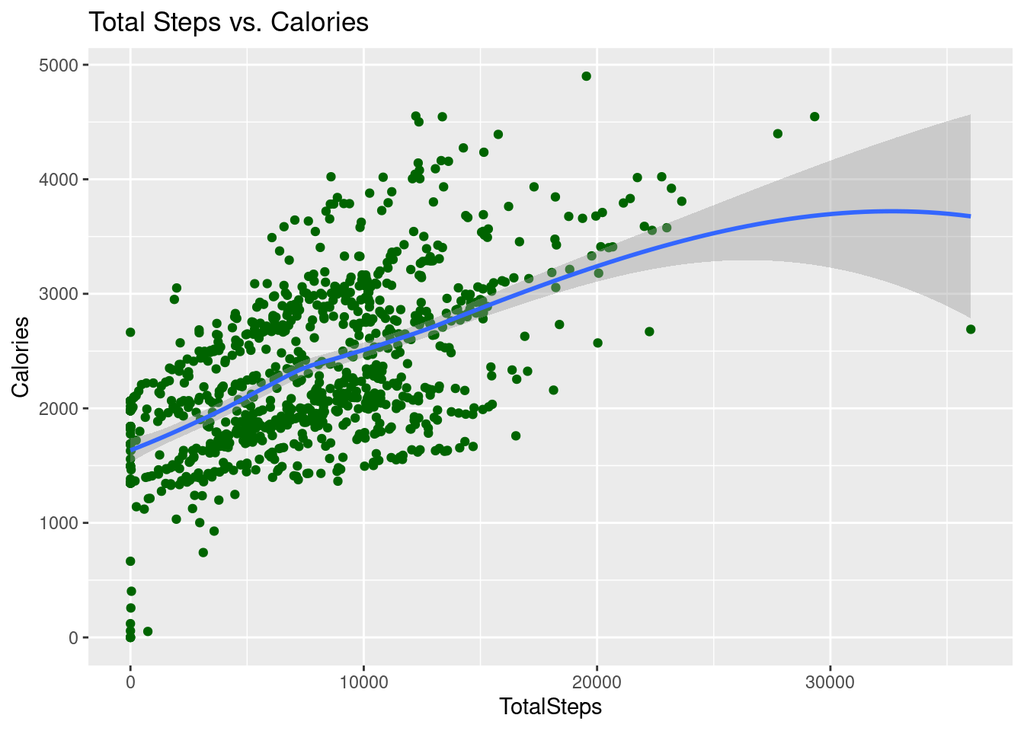

```r
ggplot(data = activity, aes(x = TotalSteps, y = Calories)) + geom_point(color = "darkgreen") + geom_smooth() + labs(title = "Total Steps vs. Calories")
```

From the scatter plot above, we observe that there exists a correlation between total number of steps taken and calories burned. The more steps each participant takes, the more calories they burn

#### Total time asleep vs Total time in bed

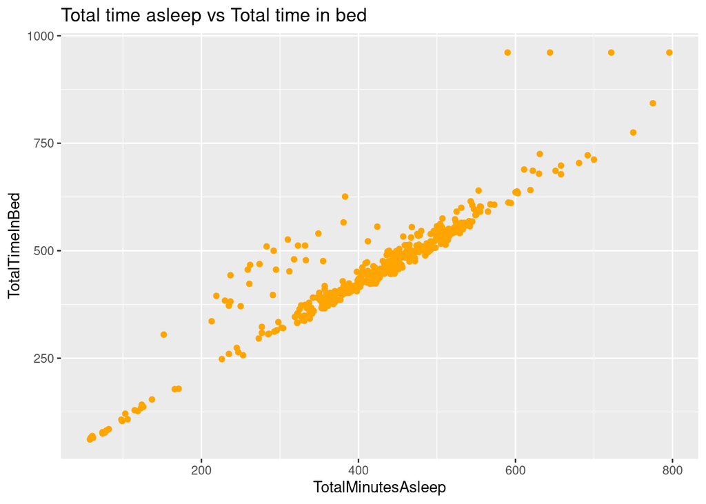

```r
ggplot(data = sleep, aes(x = TotalMinutesAsleep, y = TotalTimeInBed)) + geom_point(color='orange') + labs(title = "Total time asleep vs Total time in bed")
```

From this chart, we can see a positive correlation between total time asleep vs total time in bed. To improve sleep quality for its users, bellabeat should consider having a section where users can customize their sleep schedule to ensure consistency.

#### Sleep Duration and Sedentary Time

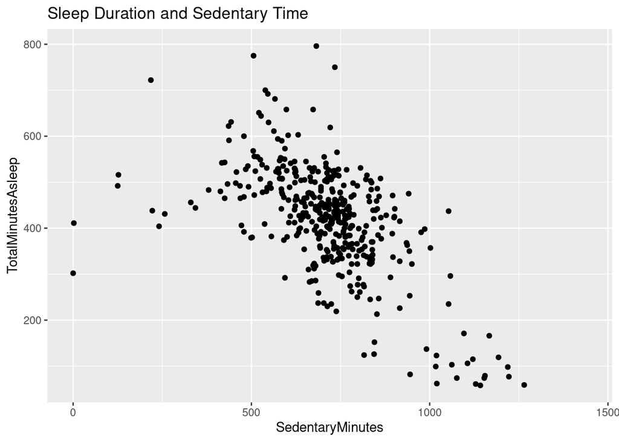

```r
ggplot(data = merged1, mapping = aes(x = SedentaryMinutes, y = TotalMinutesAsleep)) +
  geom_point() + labs(title= "Sleep Duration and Sedentary Time")
```

From looking at the graph above, we can see there is a negative correlation between SedentaryMinutes and TotalMinutesAsleep. This means that the less active a participant is, the less sleep they tend to get.

Now, we want to look at whether the day of the week affects our activity levels and sleep

```r
merged_data <- mutate(merged_data,
                      day = wday(SleepDay, label = TRUE))
summarized_activity_sleep <- merged_data %>%
  group_by(day) %>%
  summarise(AvgDailySteps = mean(TotalSteps),
            AvgAsleepMinutes = mean(TotalMinutesAsleep),
            AvgAwakeTimeInBed = mean(TotalTimeInBed),
            AvgSedentaryMinutes = mean(SedentaryMinutes),
            AvgLightlyActiveMinutes = mean(LightlyActiveMinutes),
            AvgFairlyActiveMinutes = mean(FairlyActiveMinutes),
            AvgVeryActiveMinutes = mean(VeryActiveMinutes),
            AvgCalories = mean(Calories))
summarized_activity_sleep
```

```
## # A tibble: 8 × 9
##   day   AvgDailySteps AvgAslee…¹ AvgAw…² AvgSe…³ AvgLi…⁴ AvgFa…⁵ AvgVe…⁶ AvgCa…⁷
##   <ord>         <dbl>      <dbl>   <dbl>   <dbl>   <dbl>   <dbl>   <dbl>   <dbl>
## 1 Sun           7298.       453.    504.    688.    200.    16.8    22.1   2277.
## 2 Mon           9273.       420.    457.    718.    222.    19.1    30.7   2432.
## 3 Tue           9183.       405.    443.    740.    217.    20.0    30.6   2496.
## 4 Wed           8023.       435.    470.    714.    208.    16.7    21.3   2378.
## 5 Thu           8184.       401.    435.    698.    203.    15.9    22.9   2307.
## 6 Fri           7901.       405.    445.    743.    223.    14.6    21.2   2330.
## 7 Sat           9871.       419.    460.    680.    247.    22.7    27.6   2507.
## 8 <NA>          6959.        NA      NA    1207.    174.    10.2    18.2   2237.
## # … with abbreviated variable names ¹AvgAsleepMinutes, ²AvgAwakeTimeInBed,
## #   ³AvgSedentaryMinutes, ⁴AvgLightlyActiveMinutes, ⁵AvgFairlyActiveMinutes,
## #   ⁶AvgVeryActiveMinutes, ⁷AvgCalories
```

Visualizing the same though a bar plot

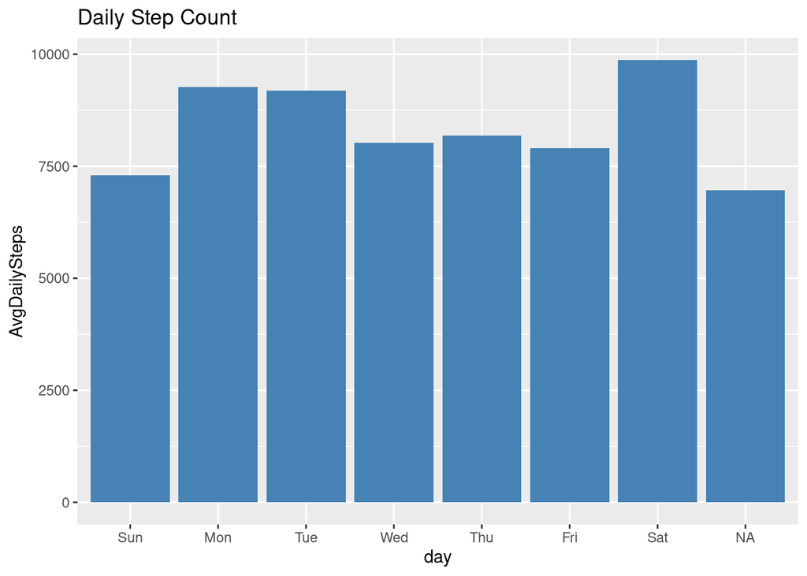

```r
ggplot(data = summarized_activity_sleep, mapping = aes(x = day, y = AvgDailySteps)) +
  geom_col(fill = "steelblue") + labs(title = "Daily Step Count")
```

The bar graph above shows us that participants are most active on saturdays and least active on sundays

#### Active minutes vs Calories

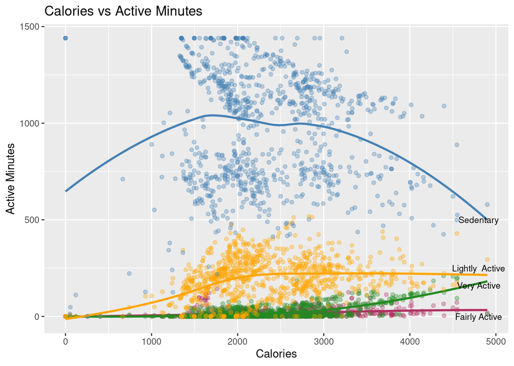

```r
active_minutes_vs_calories <- ggplot(data = merged_data) +
  geom_point(mapping=aes(x=Calories, y=FairlyActiveMinutes), color = "maroon", alpha = 1/3) +
  geom_smooth(method = loess,formula =y ~ x, mapping=aes(x=Calories, y=FairlyActiveMinutes, color=FairlyActiveMinutes), color = "maroon", se = FALSE) +

  geom_point(mapping=aes(x=Calories, y=VeryActiveMinutes), color = "forestgreen", alpha = 1/3) +
  geom_smooth(method = loess,formula =y ~ x,mapping=aes(x=Calories, y=VeryActiveMinutes, color=VeryActiveMinutes), color = "forestgreen", se = FALSE) +

  geom_point(mapping=aes(x=Calories, y=LightlyActiveMinutes), color = "orange", alpha = 1/3) +
  geom_smooth(method = loess,formula =y ~ x,mapping=aes(x=Calories, y=LightlyActiveMinutes, color=LightlyActiveMinutes), color = "orange", se = FALSE) +

  geom_point(mapping=aes(x=Calories, y=SedentaryMinutes), color = "steelblue", alpha = 1/3) +
  geom_smooth(method = loess,formula =y ~ x,mapping=aes(x=Calories, y=SedentaryMinutes, color=SedentaryeMinutes), color = "steelblue", se = FALSE) +

  annotate("text", x=4800, y=160, label="Very Active", color="black", size=3)+
  annotate("text", x=4800, y=0, label="Fairly Active", color="black", size=3)+
  annotate("text", x=4800, y=500, label="Sedentary", color="black", size=3)+
  annotate("text", x=4800, y=250, label="Lightly  Active", color="black", size=3)+
  labs(x = "Calories", y = "Active Minutes", title="Calories vs Active Minutes")
active_minutes_vs_calories
```

Through this graph, we observe that a high volume of moderate-to-vigorous physical activity is achieved by a very small proportion of the population.

### Step 6: Act

After analyzing the FitBit Fitness Tracker data, we came up with some recommendations for Bellabeat marketing strategy based on trends in smart device usage: